# About Me

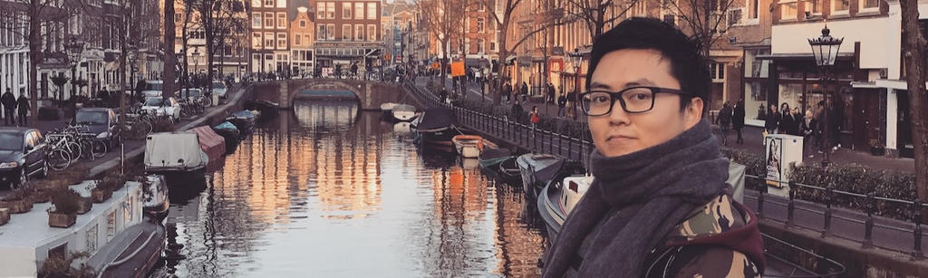

Hi! My name is Pingfan Hu. I am a PhD student and researcher at George Washington University in the Department of [Engineering Management and Systems Engineering](https://www.emse.seas.gwu.edu) with expertise in systems engineering and data analysis.

I have 4 years’ engineering working experience in top companies, and am now back to school and pursuing a PhD degree to seek for a breakthrough in academia.

My current project is a [conjoint survey](https://jhelvy.github.io/smartcharging/) for BEV (Battery Electric Vehicle) Smart Charging adoption. This project aims to understand BEV owners’ preferences with respect to participating in the Smart Charging programs to improve grid resilience and enable greater integration of renewable energy onto the grid.

## Experience and Expertise

#### My Degrees

- I have Bachelor’s degree in Industrial & Manufacturing Engineering at [Penn State University](https://www.ime.psu.edu), with a minor of Six Sigma.
- I have a Master’s degree in Mechanical Engineering at [Sydney University](https://www.sydney.edu.au/engineering/study/undergraduate-courses/mechanical-engineering.html), qualified by [Engineers Australia](https://www.engineersaustralia.org.au).

#### Professional Skills

- Experienced in [R](https://www.r-project.org) coding and R package development. I also do [Python](https://www.python.org) coding.
- Expertise in data analysis and data visualization with coding skills and commercial tools like Excel, Power BI, and Minitab.
- Proficient knowledge in vehicles, transportation, and supply chain with industrial & mechanical engineering skills.
- Engineering management capability.

#### Language Skills

- Chinese Mandarin - Native language
- English - Proficient technical writing and oral communication

## Personal Life

Throughout the past years, I have traveled and lived in different countries, including China, USA, Australia, and Germany. Now I am located at Washington DC.

I am married and having busy and enjoyable life with my wife. We have a cat named Pinocchio.

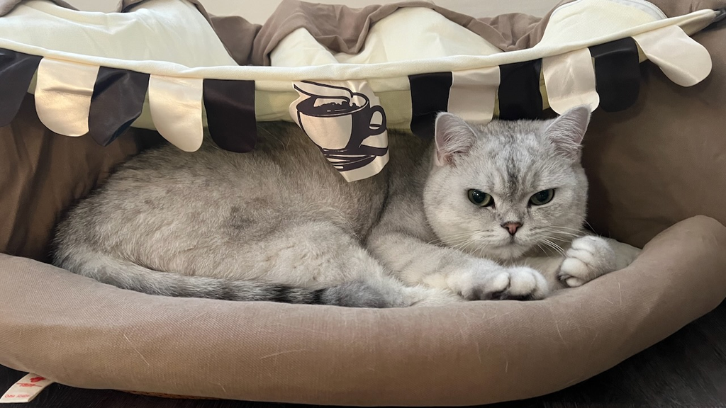

*Pinocchio*